# Predicting Churn with Machine Learning: Rmd

## April 2022

## A. Data Preparation & Exploration

```r
rm(list = ls())
```

```r
library(tidyverse)
library(dplyr)
library("readxl")
library(caret)
library(rpart)  #Classification tree
library(e1071) #Naive Bayes,
library(MASS)
library(gbm) #Boosting
library(randomForest)
library(ggplot2)
library(reshape2)
```

This is the Ecommerce Data set, available from https://www.kaggle.com/datasets/ankitverma2010/ecommerce-customer-churn-analysis-and-prediction

```r
setwd("/Users/margaretcatherman/Downloads")
discription <- read_excel("E Commerce Dataset.xlsx", sheet = "Data Dict")
df <- read_excel("E Commerce Dataset.xlsx", sheet = "E Comm")

discription
```

| Data | Variable | Discerption |
| --- | --- | --- |
| E Comm | CustomerID | Unique customer ID |
| E Comm | Churn | Churn Flag |
| E Comm | Tenure | Tenure of customer in organization |
| E Comm | PreferredLoginDevice | Preferred login device of customer |
| E Comm | CityTier | City tier |
| E Comm | WarehouseToHome | Distance in between warehouse to home of customer |
| E Comm | PreferredPaymentMode | Preferred payment method of customer |
| E Comm | Gender | Gender of customer |
| E Comm | HourSpendOnApp | Number of hours spend on mobile application or website |
| E Comm | NumberOfDeviceRegistered | Total number of deceives is registered on particular customer |

[output cut: 10 more lines]

```r
head(df)
```

| CustomerID | Churn | Tenure | PreferredLoginDevice | CityTier | WarehouseToHome | PreferredPaymentMode | Gender | HourSpendOnApp | NumberOfDeviceRegistered | PreferedOrderCat | SatisfactionScore | MaritalStatus | NumberOfAddress | Complain | OrderAmountHikeFromlastYear | CouponUsed | OrderCount | DaySinceLastOrder | CashbackAmount |
| --- | --- | --- | --- | --- | --- | --- | --- | --- | --- | --- | --- | --- | --- | --- | --- | --- | --- | --- | --- |
| 50001 | 1 | 4 | Mobile Phone | 3 | 6 | Debit Card | Female | 3 | 3 | Laptop & Accessory | 2 | Single | 9 | 1 | 11 | 1 | 1 | 5 | 159.93 |
| 50002 | 1 | NA | Phone | 1 | 8 | UPI | Male | 3 | 4 | Mobile | 3 | Single | 7 | 1 | 15 | 0 | 1 | 0 | 120.90 |
| 50003 | 1 | NA | Phone | 1 | 30 | Debit Card | Male | 2 | 4 | Mobile | 3 | Single | 6 | 1 | 14 | 0 | 1 | 3 | 120.28 |
| 50004 | 1 | 0 | Phone | 3 | 15 | Debit Card | Male | 2 | 4 | Laptop & Accessory | 5 | Single | 8 | 0 | 23 | 0 | 1 | 3 | 134.07 |
| 50005 | 1 | 0 | Phone | 1 | 12 | CC | Male | NA | 3 | Mobile | 5 | Single | 3 | 0 | 11 | 1 | 1 | 3 | 129.60 |
| 50006 | 1 | 0 | Computer | 1 | 22 | Debit Card | Female | 3 | 5 | Mobile Phone | 5 | Single | 2 | 1 | 22 | 4 | 6 | 7 | 139.19 |

```r
tail(df)
```

| CustomerID | Churn | Tenure | PreferredLoginDevice | CityTier | WarehouseToHome | PreferredPaymentMode | Gender | HourSpendOnApp | NumberOfDeviceRegistered | PreferedOrderCat | SatisfactionScore | MaritalStatus | NumberOfAddress | Complain | OrderAmountHikeFromlastYear | CouponUsed | OrderCount | DaySinceLastOrder | CashbackAmount |
| --- | --- | --- | --- | --- | --- | --- | --- | --- | --- | --- | --- | --- | --- | --- | --- | --- | --- | --- | --- |
| 55625 | 0 | 1 | Mobile Phone | 3 | 12 | UPI | Female | 2 | 5 | Mobile Phone | 3 | Single | 2 | 0 | 19 | 2 | 2 | 1 | 154.66 |
| 55626 | 0 | 10 | Computer | 1 | 30 | Credit Card | Male | 3 | 2 | Laptop & Accessory | 1 | Married | 6 | 0 | 18 | 1 | 2 | 4 | 150.71 |
| 55627 | 0 | 13 | Mobile Phone | 1 | 13 | Credit Card | Male | 3 | 5 | Fashion | 5 | Married | 6 | 0 | 16 | 1 | 2 | NA | 224.91 |
| 55628 | 0 | 1 | Mobile Phone | 1 | 11 | Debit Card | Male | 3 | 2 | Laptop & Accessory | 4 | Married | 3 | 1 | 21 | 1 | 2 | 4 | 186.42 |
| 55629 | 0 | 23 | Computer | 3 | 9 | Credit Card | Male | 4 | 5 | Laptop & Accessory | 4 | Married | 4 | 0 | 15 | 2 | 2 | 9 | 178.90 |
| 55630 | 0 | 8 | Mobile Phone | 1 | 15 | Credit Card | Male | 3 | 2 | Laptop & Accessory | 3 | Married | 4 | 0 | 13 | 2 | 2 | 3 | 169.04 |

Let’s look a the data:

```r
str(df)
```

```
tibble [5,630 × 20] (S3: tbl_df/tbl/data.frame)
 $ CustomerID                 : num [1:5630] 50001 50002 50003 50004 50005 ...
 $ Churn                      : num [1:5630] 1 1 1 1 1 1 1 1 1 1 ...
 $ Tenure                     : num [1:5630] 4 NA NA 0 0 0 NA NA 13 NA ...
 $ PreferredLoginDevice       : chr [1:5630] "Mobile Phone" "Phone" "Phone" "Phone" ...
 $ CityTier                   : num [1:5630] 3 1 1 3 1 1 3 1 3 1 ...
 $ WarehouseToHome            : num [1:5630] 6 8 30 15 12 22 11 6 9 31 ...
 $ PreferredPaymentMode       : chr [1:5630] "Debit Card" "UPI" "Debit Card" "Debit Card" ...
 $ Gender                     : chr [1:5630] "Female" "Male" "Male" "Male" ...
 $ HourSpendOnApp             : num [1:5630] 3 3 2 2 NA 3 2 3 NA 2 ...
 $ NumberOfDeviceRegistered   : num [1:5630] 3 4 4 4 3 5 3 3 4 5 ...
 $ PreferedOrderCat           : chr [1:5630] "Laptop & Accessory" "Mobile" "Mobile" "Laptop & Accessory" ...
 $ SatisfactionScore          : num [1:5630] 2 3 3 5 5 5 2 2 3 3 ...
 $ MaritalStatus              : chr [1:5630] "Single" "Single" "Single" "Single" ...
 $ NumberOfAddress            : num [1:5630] 9 7 6 8 3 2 4 3 2 2 ...
 $ Complain                   : num [1:5630] 1 1 1 0 0 1 0 1 1 0 ...
 $ OrderAmountHikeFromlastYear: num [1:5630] 11 15 14 23 11 22 14 16 14 12 ...
 $ CouponUsed                 : num [1:5630] 1 0 0 0 1 4 0 2 0 1 ...
 $ OrderCount                 : num [1:5630] 1 1 1 1 1 6 1 2 1 1 ...
 $ DaySinceLastOrder          : num [1:5630] 5 0 3 3 3 7 0 0 2 1 ...
 $ CashbackAmount             : num [1:5630] 160 121 120 134 130 ...
```

```r
#Hmisc::describe(df)
```

Let’s check for missing data;

```r
dim(df)
```

```
[1] 5630   20
```

```r
sum(is.na(df))
```

```
[1] 1856
```

While this is substantial, we will omit missing values For now, we will remove all rows w NA:

```r
df.1 <- na.omit(df)
head(df.1)  #df omiting NA
```

| CustomerID | Churn | Tenure | PreferredLoginDevice | CityTier | WarehouseToHome | PreferredPaymentMode | Gender | HourSpendOnApp | NumberOfDeviceRegistered | PreferedOrderCat | SatisfactionScore | MaritalStatus | NumberOfAddress | Complain | OrderAmountHikeFromlastYear | CouponUsed | OrderCount | DaySinceLastOrder | CashbackAmount |
| --- | --- | --- | --- | --- | --- | --- | --- | --- | --- | --- | --- | --- | --- | --- | --- | --- | --- | --- | --- |
| 50001 | 1 | 4 | Mobile Phone | 3 | 6 | Debit Card | Female | 3 | 3 | Laptop & Accessory | 2 | Single | 9 | 1 | 11 | 1 | 1 | 5 | 159.93 |
| 50004 | 1 | 0 | Phone | 3 | 15 | Debit Card | Male | 2 | 4 | Laptop & Accessory | 5 | Single | 8 | 0 | 23 | 0 | 1 | 3 | 134.07 |
| 50006 | 1 | 0 | Computer | 1 | 22 | Debit Card | Female | 3 | 5 | Mobile Phone | 5 | Single | 2 | 1 | 22 | 4 | 6 | 7 | 139.19 |
| 50012 | 1 | 11 | Mobile Phone | 1 | 6 | Debit Card | Male | 3 | 4 | Fashion | 3 | Single | 10 | 1 | 13 | 0 | 1 | 0 | 153.81 |
| 50013 | 1 | 0 | Phone | 1 | 11 | COD | Male | 2 | 3 | Mobile | 3 | Single | 2 | 1 | 13 | 2 | 2 | 2 | 134.41 |
| 50014 | 1 | 0 | Phone | 1 | 15 | CC | Male | 3 | 4 | Mobile | 3 | Divorced | 1 | 1 | 17 | 0 | 1 | 0 | 133.88 |

The Ecommerce Data set with missing values removed:

```r
sum(is.na(df.1))
```

```
[1] 0
```

```r
dim(df.1)
```

```
[1] 3774   20
```

Create dummy variables for all character/categorical variables, following several steps:

1. Pull all character/categorical variables together

```r
df.char <- df.1 %>%
  select_if(is.character)

head(df.char)
```

| PreferredLoginDevice | PreferredPaymentMode | Gender | PreferedOrderCat | MaritalStatus |
| --- | --- | --- | --- | --- |
| Mobile Phone | Debit Card | Female | Laptop & Accessory | Single |
| Phone | Debit Card | Male | Laptop & Accessory | Single |
| Computer | Debit Card | Female | Mobile Phone | Single |
| Mobile Phone | Debit Card | Male | Fashion | Single |
| Phone | COD | Male | Mobile | Single |
| Phone | CC | Male | Mobile | Divorced |

Let’s take a look:

```r
str(df.char)
```

```
tibble [3,774 × 5] (S3: tbl_df/tbl/data.frame)
 $ PreferredLoginDevice: chr [1:3774] "Mobile Phone" "Phone" "Computer" "Mobile Phone" ...
 $ PreferredPaymentMode: chr [1:3774] "Debit Card" "Debit Card" "Debit Card" "Debit Card" ...
 $ Gender              : chr [1:3774] "Female" "Male" "Female" "Male" ...
 $ PreferedOrderCat    : chr [1:3774] "Laptop & Accessory" "Laptop & Accessory" "Mobile Phone" "Fashion" ...
 $ MaritalStatus       : chr [1:3774] "Single" "Single" "Single" "Single" ...
 - attr(*, "na.action")= 'omit' Named int [1:1856] 2 3 5 7 8 9 10 11 16 17 ...
  ..- attr(*, "names")= chr [1:1856] "2" "3" "5" "7" ...
```

2. df.num <- Put all initially numeric variables together

```r
df.num <- df.1 %>%
  select_if(is.numeric)
head(df.num,3)
```

| CustomerID | Churn | Tenure | CityTier | WarehouseToHome | HourSpendOnApp | NumberOfDeviceRegistered | SatisfactionScore | NumberOfAddress | Complain | OrderAmountHikeFromlastYear | CouponUsed | OrderCount | DaySinceLastOrder | CashbackAmount |
| --- | --- | --- | --- | --- | --- | --- | --- | --- | --- | --- | --- | --- | --- | --- |
| 50001 | 1 | 4 | 3 | 6 | 3 | 3 | 2 | 9 | 1 | 11 | 1 | 1 | 5 | 159.93 |
| 50004 | 1 | 0 | 3 | 15 | 2 | 4 | 5 | 8 | 0 | 23 | 0 | 1 | 3 | 134.07 |
| 50006 | 1 | 0 | 1 | 22 | 3 | 5 | 5 | 2 | 1 | 22 | 4 | 6 | 7 | 139.19 |

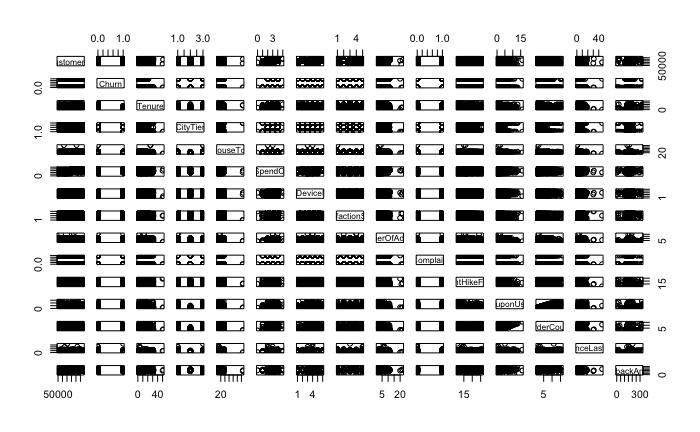

```r
pairs(df.num)
```

# Automatically dummify the character data

Data Mining for business Analytics: Concepts, Techniques, and applications in R, Shmueli, et al;Catagroical Catagorical predictors for Classification trees should be converted to dummy variables. As w KNN, a factor w m catagories, m>2, should be factored into m dummy variables, NOT m-1. (p 209)

```r
dmy <- dummyVars(" ~ .", data = df.char)
trsf <- data.frame(predict(dmy, newdata = df.char))
head(trsf)
```

|  | PreferredLoginDeviceComputer | PreferredLoginDeviceMobile.Phone | PreferredLoginDevicePhone | PreferredPaymentModeCash.on.Delivery | PreferredPaymentModeCC | PreferredPaymentModeCOD | PreferredPaymentModeCredit.Card | PreferredPaymentModeDebit.Card | PreferredPaymentModeE.wallet | PreferredPaymentModeUPI | GenderFemale | GenderMale | PreferedOrderCatFashion | PreferedOrderCatGrocery | PreferedOrderCatLaptop...Accessory | PreferedOrderCatMobile | PreferedOrderCatMobile.Phone | PreferedOrderCatOthers | MaritalStatusDivorced | MaritalStatusMarried | MaritalStatusSingle |
| --- | --- | --- | --- | --- | --- | --- | --- | --- | --- | --- | --- | --- | --- | --- | --- | --- | --- | --- | --- | --- | --- |
| 1 | 0 | 1 | 0 | 0 | 0 | 0 | 0 | 1 | 0 | 0 | 1 | 0 | 0 | 0 | 1 | 0 | 0 | 0 | 0 | 0 | 1 |
| 2 | 0 | 0 | 1 | 0 | 0 | 0 | 0 | 1 | 0 | 0 | 0 | 1 | 0 | 0 | 1 | 0 | 0 | 0 | 0 | 0 | 1 |
| 3 | 1 | 0 | 0 | 0 | 0 | 0 | 0 | 1 | 0 | 0 | 1 | 0 | 0 | 0 | 0 | 0 | 1 | 0 | 0 | 0 | 1 |
| 4 | 0 | 1 | 0 | 0 | 0 | 0 | 0 | 1 | 0 | 0 | 0 | 1 | 1 | 0 | 0 | 0 | 0 | 0 | 0 | 0 | 1 |
| 5 | 0 | 0 | 1 | 0 | 0 | 1 | 0 | 0 | 0 | 0 | 0 | 1 | 0 | 0 | 0 | 1 | 0 | 0 | 0 | 0 | 1 |
| 6 | 0 | 0 | 1 | 0 | 1 | 0 | 0 | 0 | 0 | 0 | 0 | 1 | 0 | 0 | 0 | 1 | 0 | 0 | 1 | 0 | 0 |

```r
setwd("/Users/margaretcatherman/Downloads")
write.csv(data, "Churn_prepped.csv", row.names = FALSE)
```

Standardize data: Not needed for RF, but is needed for some other methods that will be used.

Scale Data min-max scaling: The data is scaled to a fixed range: 0 to 1. This results in smaller standard deviations, which helps supress effect of outliers.

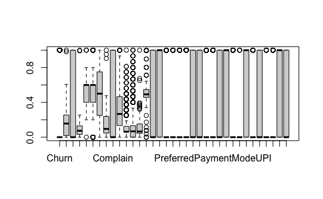

```r
preproc <- preProcess(data[,c(2:36)], method = c("range"))
norm.df <- predict(preproc, data[,c(2:36)])
boxplot(norm.df)
```

```r
set.seed(7406)

n = dim(norm.df)[1]  #total # observations
n1 = round(n/3)   #no. observations randomly selected for testing

flag = sort(sample(1:n, n1))
train = norm.df[-flag,]
test = norm.df[flag,]

dim(train)
```

```
[1] 2516   35
```

```r
dim(test)
```

```
[1] 1258   35
```

```r
head(train,3)
```

|  | Churn | Tenure | CityTier | WarehouseToHome | HourSpendOnApp | NumberOfDeviceRegistered | SatisfactionScore | NumberOfAddress | Complain | OrderAmountHikeFromlastYear | CouponUsed | OrderCount | DaySinceLastOrder | CashbackAmount | PreferredLoginDeviceComputer | PreferredLoginDeviceMobile.Phone | PreferredLoginDevicePhone | PreferredPaymentModeCash.on.Delivery | PreferredPaymentModeCC | PreferredPaymentModeCOD | PreferredPaymentModeCredit.Card | PreferredPaymentModeDebit.Card | PreferredPaymentModeE.wallet | PreferredPaymentModeUPI | GenderFemale | GenderMale | PreferedOrderCatFashion | PreferedOrderCatGrocery | PreferedOrderCatLaptop...Accessory | … |
| --- | --- | --- | --- | --- | --- | --- | --- | --- | --- | --- | --- | --- | --- | --- | --- | --- | --- | --- | --- | --- | --- | --- | --- | --- | --- | --- | --- | --- | --- | --- |
| 1 | 1 | 0.07843137 | 1 | 0.008196721 | 0.6 | 0.4 | 0.25 | 0.38095238 | 1 | 0.0000000 | 0.0625 | 0.0000000 | 0.10869565 | 0.4921074 | 0 | 1 | 0 | 0 | 0 | 0 | 0 | 1 | 0 | 0 | 1 | 0 | 0 | 0 | 1 | … |
| 2 | 1 | 0.00000000 | 1 | 0.081967213 | 0.4 | 0.6 | 1.00 | 0.33333333 | 0 | 0.8000000 | 0.0000 | 0.0000000 | 0.06521739 | 0.4125358 | 0 | 0 | 1 | 0 | 0 | 0 | 0 | 1 | 0 | 0 | 0 | 1 | 0 | 0 | 1 | … |
| 3 | 1 | 0.00000000 | 0 | 0.139344262 | 0.6 | 0.8 | 1.00 | 0.04761905 | 1 | 0.7333333 | 0.2500 | 0.3333333 | 0.15217391 | 0.4282901 | 1 | 0 | 0 | 0 | 0 | 0 | 0 | 1 | 0 | 0 | 1 | 0 | 0 | 0 | 0 | … |

```r
head(test,3)
```

|  | Churn | Tenure | CityTier | WarehouseToHome | HourSpendOnApp | NumberOfDeviceRegistered | SatisfactionScore | NumberOfAddress | Complain | OrderAmountHikeFromlastYear | CouponUsed | OrderCount | DaySinceLastOrder | CashbackAmount | PreferredLoginDeviceComputer | PreferredLoginDeviceMobile.Phone | PreferredLoginDevicePhone | PreferredPaymentModeCash.on.Delivery | PreferredPaymentModeCC | PreferredPaymentModeCOD | PreferredPaymentModeCredit.Card | PreferredPaymentModeDebit.Card | PreferredPaymentModeE.wallet | PreferredPaymentModeUPI | GenderFemale | GenderMale | PreferedOrderCatFashion | PreferedOrderCatGrocery | PreferedOrderCatLaptop...Accessory | … |
| --- | --- | --- | --- | --- | --- | --- | --- | --- | --- | --- | --- | --- | --- | --- | --- | --- | --- | --- | --- | --- | --- | --- | --- | --- | --- | --- | --- | --- | --- | --- |
| 4 | 1 | 0.2156863 | 0 | 0.008196721 | 0.6 | 0.6 | 0.50 | 0.42857143 | 1 | 0.1333333 | 0 | 0.0 | 0.0000000 | 0.4732761 | 0 | 1 | 0 | 0 | 0 | 0 | 0 | 1 | 0 | 0 | 0 | 1 | 1 | 0 | 0 | … |
| 6 | 1 | 0.0000000 | 0 | 0.081967213 | 0.6 | 0.6 | 0.50 | 0.00000000 | 1 | 0.4000000 | 0 | 0.0 | 0.0000000 | 0.4119511 | 0 | 0 | 1 | 0 | 1 | 0 | 0 | 0 | 0 | 0 | 0 | 1 | 0 | 0 | 0 | … |
| 7 | 1 | 0.1764706 | 1 | 0.081967213 | 0.6 | 0.6 | 0.25 | 0.04761905 | 0 | 0.3333333 | 0 | 0.2 | 0.1521739 | 0.6036801 | 0 | 1 | 0 | 0 | 0 | 0 | 1 | 0 | 0 | 0 | 0 | 1 | 1 | 0 | 0 | … |

Extra the true response value for training and testing data

```r
y1 <- train$Churn
y2 <- test$Churn
```

train Feature Selection for Classification: Recursive feature elimination, Boruta, Random Forests

## 1. RandomForests Classification

```r
library(randomForest)
set.seed(123)

rf <- randomForest(as.factor(Churn) ~., data = train, mtry = sqrt(34), importance = TRUE)
```

RF: Training error prediction & confusion matrix

```r
rf.pred.train = predict(rf, train, type='class')
table(rf.pred.train, y1)
```

```
             y1
rf.pred.train    0    1
            0 2100    0
            1    0  416
```

RF: Training error rate w ibe round of RF

```r
y1hat.rf.train = predict(rf, train, type='class')
mean(y1hat.rf.train != y1)
```

```
[1] 0
```

RF: Test error prediction & confusion matrix

```r
rf.pred.test = predict(rf, test, type='class')
table(rf.pred.test, y2)
```

```
            y2
rf.pred.test    0    1
           0 1036   42
           1    7  173
```

RF: Test error rate

```r
#.038
y2hat.rf.test = predict(rf, test, type='class')
a <- mean(y2hat.rf.test != y2)
a
```

```
[1] 0.03895072
```

Use tuneRF to improve parameteres:

```
-0.3404255 0.01
0.1631206 0.01
0.05932203 0.01
0.02702703 0.01
0.0462963 0.01
-0.04854369 0.01
```

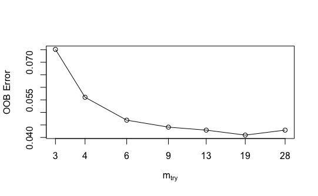

```r
# names of features
features <- setdiff(names(train), as.factor("Churn"))

set.seed(123)

m2 <- tuneRF(
  x          = train[features],
  y          = as.factor(train$Churn),
  #y          = train$Churn,
  ntreeTry   = 500,
  mtryStart  = 4,
  stepFactor = 1.5,
  improve    = 0.01,
  trace      = FALSE,
  type       = 'class'            # to not show real-time progress
)
```

We see that the optimal number for mytry is 19

Let’s apply the optimal value of 19 to mtry & change some other paramters and see if error rate is improved?

```r
set.seed(123)
#no of rows train data = 2516; no of rows test data = 1258
rfb <- randomForest(as.factor(Churn) ~., data=train, ntree= 500,
                   mtry = 19, nodesize = 1,  importance = TRUE)
```

RF: Training error prediction & confusion matrix

```r
rfb.pred.train = predict(rfb, train, type='class')
table(rfb.pred.train, y1)
```

```
              y1
rfb.pred.train    0    1
             0 2100    0
             1    0  416
```

RF: Test error prediction & confusion matrix

```r
rfb.pred.test = predict(rfb, test, type='class')
table(rfb.pred.test, y2)
```

```
             y2
rfb.pred.test    0    1
            0 1032   31
            1   11  184
```

RF: Test error rate

```r
#.038
y2hat.rfb.test = predict(rfb, test, type='class')
b <- mean(y2hat.rfb.test != y2)
b
```

```
[1] 0.03338633
```

#Resume Check Important features here for RF

```r
## Check Important variables
#importance(rfb)
## There are two types of importance measure
##  (1=mean decrease in accuracy,
##   2= mean decrease in node impurity)
importance(rfb, type=2)
```

```
                                     MeanDecreaseGini
Tenure                                   2.003564e+02
CityTier                                 1.193826e+01
WarehouseToHome                          4.709126e+01
HourSpendOnApp                           9.352270e+00
NumberOfDeviceRegistered                 2.273610e+01
SatisfactionScore                        2.738632e+01
NumberOfAddress                          5.842421e+01
Complain                                 4.221160e+01
OrderAmountHikeFromlastYear              3.163358e+01
CouponUsed                               1.446649e+01
OrderCount                               1.667397e+01
DaySinceLastOrder                        4.281905e+01
CashbackAmount                           5.311574e+01
PreferredLoginDeviceComputer             1.184282e+01
PreferredLoginDeviceMobile.Phone         5.339705e+00
PreferredLoginDevicePhone                4.449495e+00
PreferredPaymentModeCash.on.Delivery     5.713143e-01
PreferredPaymentModeCC                   7.561999e-01
PreferredPaymentModeCOD                  8.482643e+00
PreferredPaymentModeCredit.Card          6.647567e+00
PreferredPaymentModeDebit.Card           6.242686e+00
PreferredPaymentModeE.wallet             6.659351e+00
PreferredPaymentModeUPI                  3.126001e+00
GenderFemale                             6.931496e+00
GenderMale                               6.291462e+00
PreferedOrderCatFashion                  3.067778e+00
PreferedOrderCatGrocery                  8.631579e-03
PreferedOrderCatLaptop...Accessory       1.085546e+01
PreferedOrderCatMobile                   9.616006e-01
PreferedOrderCatMobile.Phone             7.731902e+00
PreferedOrderCatOthers                   6.707449e-01
MaritalStatusDivorced                    3.137353e+00
MaritalStatusMarried                     6.328619e+00
MaritalStatusSingle                      1.558914e+01
```

```r
#varImpPlot(rfb)
```

[figure not shown]

```r
varImpPlot(rfb)
```

```r
sqrt(34)
```

```
[1] 5.830952
```

```r
34/3
```

```
[1] 11.33333
```

## 2. Boosting

http://uc-r.github.io/gbm_regression

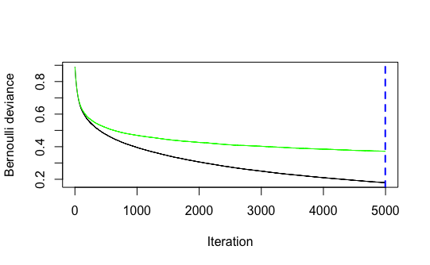

```r
## You need to first install this R package before using it
library(gbm)
###
# reproducibility
set.seed(123)

gbm1 <- gbm(Churn ~ .,
                 data = train,
                 distribution = 'bernoulli', #for classifcation
                   n.trees = 5000,            #The parameter M
                   shrinkage = 0.01,          #The value lambda, default = .01
                   interaction.depth = 3,      #interactions between x's
                   cv.folds = 10)
## Model Inspection
## Find the estimated optimal number of iterations
perf_gbm1 = gbm.perf(gbm1, method="cv")
```

```r
perf_gbm1
```

```
[1] 4996
```

|  | var | rel.inf |
| --- | --- | --- |
| Tenure | Tenure | 33.467486880 |
| CashbackAmount | CashbackAmount | 10.233977467 |
| NumberOfAddress | NumberOfAddress | 9.308106080 |
| Complain | Complain | 7.018215739 |
| WarehouseToHome | WarehouseToHome | 5.849511759 |
| DaySinceLastOrder | DaySinceLastOrder | 5.385271343 |
| SatisfactionScore | SatisfactionScore | 4.420979648 |
| OrderAmountHikeFromlastYear | OrderAmountHikeFromlastYear | 3.637431537 |
| NumberOfDeviceRegistered | NumberOfDeviceRegistered | 3.107515567 |
| MaritalStatusSingle | MaritalStatusSingle | 2.683183406 |

[output cut: 24 more lines]

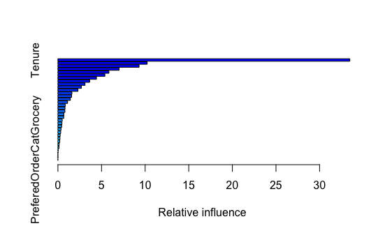

```r
## summary model
## Which variances are important
summary(gbm1)
```

Top three variables by importance: Tenure, CashbackAmount, NumberofAddress, for Boosting, as well as with Gini from RF. Tenure is significantly higher in both. Going forward, could use these three, or Tenure by itself.

Training error

```r
## Make Prediction
## use "predict" to find the training or testing error

## Training error
pred1gbm <- predict(gbm1, newdata = train, n.trees=perf_gbm1, type="response")
pred1gbm[1:10]
```

```
 [1] 0.4648581 0.9405431 0.9983061 0.9183708 0.7648098 0.9020515 0.4700702 0.9956607 0.7682920 0.5969639
```

```r
y1hat <- ifelse(pred1gbm < 0.5, 0, 1)
y1hat[1:10]
```

```
 [1] 0 1 1 1 1 1 0 1 1 1
```

```r
sum(y1hat != y1)/length(y1)  ##Training error
```

```
[1] 0.02305246
```

Testing Error

```r
## Testing Error
y2hat <- ifelse(predict(gbm1, newdata = test[,-1], n.trees=perf_gbm1,type="response") < 0.5, 0, 1)
c <- mean(y2hat != y2)
c
```

```
[1] 0.07392687
```

##### Manually guess at some improvements ###$

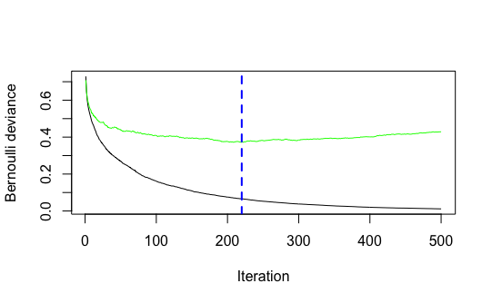

```r
# reproducibility
set.seed(123)

gbm2 <- gbm(Churn ~ .,
                 data = train,
                 distribution = 'bernoulli', #for classifcation
                   n.trees = 500,            #The parameter M
                   shrinkage = 0.3,          #The value lambda, default = .01
                   interaction.depth = 5,      #interactions between x's
                   cv.folds = 10)                # K > 0 for cv

## Find the estimated optimal number of iterations
perf_gbm2 = gbm.perf(gbm2, method="cv")
```

```r
perf_gbm2
```

```
[1] 220
```

|  | var | rel.inf |
| --- | --- | --- |
| Tenure | Tenure | 27.770994355 |
| CashbackAmount | CashbackAmount | 11.204460476 |
| NumberOfAddress | NumberOfAddress | 8.623622085 |
| DaySinceLastOrder | DaySinceLastOrder | 6.402974797 |
| WarehouseToHome | WarehouseToHome | 5.742195870 |
| OrderAmountHikeFromlastYear | OrderAmountHikeFromlastYear | 5.267244689 |
| Complain | Complain | 5.244294400 |
| SatisfactionScore | SatisfactionScore | 4.943352547 |
| NumberOfDeviceRegistered | NumberOfDeviceRegistered | 3.540160369 |
| PreferredLoginDeviceComputer | PreferredLoginDeviceComputer | 2.698316424 |

[output cut: 24 more lines]

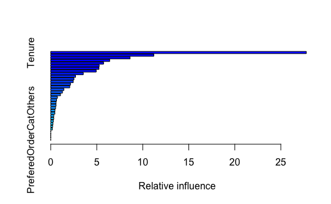

```r
## Which variances are important? Boosting Round 2  #220
summary(gbm2)
```

```r
## Training error
pred1gbm2 <- predict(gbm2, newdata = train, n.trees=perf_gbm2, type="response")
pred1gbm2[1:10]
```

```
 [1] 0.7603696 0.9812978 0.9999773 0.9865527 0.8406706 0.9863272 0.6184700 0.9923137 0.8758050 0.8461230
```

```r
y1hat2 <- ifelse(pred1gbm2 < 0.5, 0, 1)
y1hat2[1:10]
```

```
 [1] 1 1 1 1 1 1 1 1 1 1
```

```r
sum(y1hat2 != y1)/length(y1)  ##Training error
```

```
[1] 0.002384738
```

Testing Error

```r
## Testing Error
y2hat2 <- ifelse(predict(gbm2, newdata = test[,-1], n.trees=perf_gbm2,type="response") < 0.5, 0, 1)
d <- mean(y2hat2 != y2)
d
```

```
[1] 0.06041335
```

gbm9 Run w top 9 predictors

Row # for order count 12, prefed log in computer 15,

```r
head(train,3)
```

|  | Churn | Tenure | CityTier | WarehouseToHome | HourSpendOnApp | NumberOfDeviceRegistered | SatisfactionScore | NumberOfAddress | Complain | OrderAmountHikeFromlastYear | CouponUsed | OrderCount | DaySinceLastOrder | CashbackAmount | PreferredLoginDeviceComputer | PreferredLoginDeviceMobile.Phone | PreferredLoginDevicePhone | PreferredPaymentModeCash.on.Delivery | PreferredPaymentModeCC | PreferredPaymentModeCOD | PreferredPaymentModeCredit.Card | PreferredPaymentModeDebit.Card | PreferredPaymentModeE.wallet | PreferredPaymentModeUPI | GenderFemale | GenderMale | PreferedOrderCatFashion | PreferedOrderCatGrocery | PreferedOrderCatLaptop...Accessory | … |
| --- | --- | --- | --- | --- | --- | --- | --- | --- | --- | --- | --- | --- | --- | --- | --- | --- | --- | --- | --- | --- | --- | --- | --- | --- | --- | --- | --- | --- | --- | --- |
| 1 | 1 | 0.07843137 | 1 | 0.008196721 | 0.6 | 0.4 | 0.25 | 0.38095238 | 1 | 0.0000000 | 0.0625 | 0.0000000 | 0.10869565 | 0.4921074 | 0 | 1 | 0 | 0 | 0 | 0 | 0 | 1 | 0 | 0 | 1 | 0 | 0 | 0 | 1 | … |
| 2 | 1 | 0.00000000 | 1 | 0.081967213 | 0.4 | 0.6 | 1.00 | 0.33333333 | 0 | 0.8000000 | 0.0000 | 0.0000000 | 0.06521739 | 0.4125358 | 0 | 0 | 1 | 0 | 0 | 0 | 0 | 1 | 0 | 0 | 0 | 1 | 0 | 0 | 1 | … |
| 3 | 1 | 0.00000000 | 0 | 0.139344262 | 0.6 | 0.8 | 1.00 | 0.04761905 | 1 | 0.7333333 | 0.2500 | 0.3333333 | 0.15217391 | 0.4282901 | 1 | 0 | 0 | 0 | 0 | 0 | 0 | 1 | 0 | 0 | 1 | 0 | 0 | 0 | 0 | … |

```r
head(test,3)
```

|  | Churn | Tenure | CityTier | WarehouseToHome | HourSpendOnApp | NumberOfDeviceRegistered | SatisfactionScore | NumberOfAddress | Complain | OrderAmountHikeFromlastYear | CouponUsed | OrderCount | DaySinceLastOrder | CashbackAmount | PreferredLoginDeviceComputer | PreferredLoginDeviceMobile.Phone | PreferredLoginDevicePhone | PreferredPaymentModeCash.on.Delivery | PreferredPaymentModeCC | PreferredPaymentModeCOD | PreferredPaymentModeCredit.Card | PreferredPaymentModeDebit.Card | PreferredPaymentModeE.wallet | PreferredPaymentModeUPI | GenderFemale | GenderMale | PreferedOrderCatFashion | PreferedOrderCatGrocery | PreferedOrderCatLaptop...Accessory | … |
| --- | --- | --- | --- | --- | --- | --- | --- | --- | --- | --- | --- | --- | --- | --- | --- | --- | --- | --- | --- | --- | --- | --- | --- | --- | --- | --- | --- | --- | --- | --- |
| 4 | 1 | 0.2156863 | 0 | 0.008196721 | 0.6 | 0.6 | 0.50 | 0.42857143 | 1 | 0.1333333 | 0 | 0.0 | 0.0000000 | 0.4732761 | 0 | 1 | 0 | 0 | 0 | 0 | 0 | 1 | 0 | 0 | 0 | 1 | 1 | 0 | 0 | … |
| 6 | 1 | 0.0000000 | 0 | 0.081967213 | 0.6 | 0.6 | 0.50 | 0.00000000 | 1 | 0.4000000 | 0 | 0.0 | 0.0000000 | 0.4119511 | 0 | 0 | 1 | 0 | 1 | 0 | 0 | 0 | 0 | 0 | 0 | 1 | 0 | 0 | 0 | … |
| 7 | 1 | 0.1764706 | 1 | 0.081967213 | 0.6 | 0.6 | 0.25 | 0.04761905 | 0 | 0.3333333 | 0 | 0.2 | 0.1521739 | 0.6036801 | 0 | 1 | 0 | 0 | 0 | 0 | 1 | 0 | 0 | 0 | 0 | 1 | 1 | 0 | 0 | … |

```r
#Churn 1, Tenure 2, CashbackAmount 15, NumberofAddress 9,
#remove order count 13
top.9.train <- train[,c(1,2,4,6:10,13,14)]
top.9.test <- test[,c(1,2,4,6:10,13,14)]

top.9.train
```

|  | Churn | Tenure | WarehouseToHome | NumberOfDeviceRegistered | SatisfactionScore | NumberOfAddress | Complain | OrderAmountHikeFromlastYear | DaySinceLastOrder | CashbackAmount |
| --- | --- | --- | --- | --- | --- | --- | --- | --- | --- | --- |
| 1 | 1 | 0.07843137 | 0.008196721 | 0.4 | 0.25 | 0.38095238 | 1 | 0.00000000 | 0.10869565 | 0.49210745 |
| 2 | 1 | 0.00000000 | 0.081967213 | 0.6 | 1.00 | 0.33333333 | 0 | 0.80000000 | 0.06521739 | 0.41253577 |
| 3 | 1 | 0.00000000 | 0.139344262 | 0.8 | 1.00 | 0.04761905 | 1 | 0.73333333 | 0.15217391 | 0.42829010 |
| 5 | 1 | 0.00000000 | 0.049180328 | 0.4 | 0.50 | 0.04761905 | 1 | 0.13333333 | 0.04347826 | 0.41358196 |
| 8 | 1 | 0.00000000 | 0.049180328 | 0.6 | 0.50 | 0.04761905 | 1 | 0.00000000 | 0.06521739 | 0.48444568 |
| 9 | 1 | 0.00000000 | 0.065573770 | 0.8 | 0.50 | 0.04761905 | 1 | 0.86666667 | 0.13043478 | 0.49459983 |
| 10 | 1 | 0.37254902 | 0.122950820 | 0.4 | 0.75 | 0.42857143 | 1 | 0.46666667 | 0.06521739 | 0.46041417 |
| 11 | 1 | 0.00000000 | 0.057377049 | 0.8 | 0.50 | 0.19047619 | 1 | 0.46666667 | 0.15217391 | 0.49761531 |
| 12 | 1 | 0.39215686 | 0.196721311 | 0.4 | 0.25 | 0.04761905 | 0 | 0.06666667 | 0.13043478 | 0.62500385 |
| 14 | 1 | 0.27450980 | 0.073770492 | 0.8 | 0.25 | 0.09523810 | 0 | 0.26666667 | 0.06521739 | 0.63540417 |

[output cut: 990 more lines]

rf9 RF w top 9

```r
set.seed(123)
rf9 <- randomForest(as.factor(Churn) ~., data = top.9.train, mtry = sqrt(9), importance = TRUE)

#rf.pred.train = predict(rf, train, type='class')
#table(rf.pred.train, y1)

#RF: Test error prediction & confusion matrix
#rf9.pred.test = predict(rf9, top.9.test, type='class')
#table(rf9.pred.test, y2)

y2hat.rf9.test = predict(rf9, top.9.test, type='class')
a9 <- mean(y2hat.rf9.test != y2)
a9
```

```
[1] 0.03736089
```

frb9 Top 9 w optimizerd rfb will need to slightly adjust optimization: sqrt of p; p is now 9

```r
set.seed(123)
#no of rows train data = 2516; no of rows test data = 1258
rfb9 <- randomForest(as.factor(Churn) ~., data=top.9.train, ntree= 500,
                   mtry = 3, nodesize = 1,  importance = TRUE)


#rf.pred.train = predict(rf, train, type='class')
#table(rf.pred.train, y1)

#RF: Test error prediction & confusion matrix
#rf9.pred.test = predict(rf9, top.9.test, type='class')
#table(rf9.pred.test, y2)

y2hat.rfb9.test = predict(rfb9, top.9.test, type='class')
b9 <- mean(y2hat.rfb9.test != y2)
b9
```

```
[1] 0.03736089
```

0.03736089

```
-0.08256881 0.01
0.03669725 0.01
-0.04761905 0.01
```

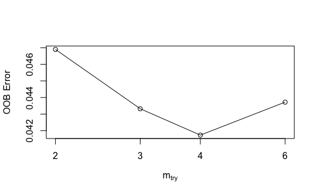

```r
# names of features
features9 <- setdiff(names(top.9.train), as.factor("Churn"))

set.seed(123)

m29 <- tuneRF(
  x          = top.9.train[features9],
  y          = as.factor(top.9.train$Churn),
  #y          = top.9.train$Churn,
  ntreeTry   = 500,
  mtryStart  = 3,
  stepFactor = 1.5,
  improve    = 0.01,
  trace      = FALSE,
  type       = 'class'            # to not show real-time progress
)
```

## Find the estimated optimal number of iterations

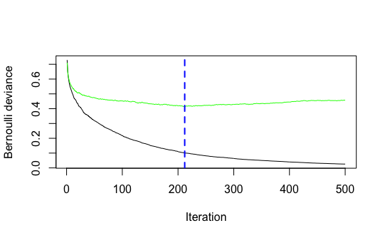

```r
# reproducibility
set.seed(123)

gbm29 <- gbm(Churn ~ .,
                 data = top.9.train,
                 distribution = 'bernoulli', #for classifcation
                   n.trees = 500,            #The parameter M
                   shrinkage = 0.3,          #The value lambda, default = .01
                   interaction.depth = 5,      #interactions between x's
                   cv.folds = 10)                # K > 0 for cv

## Find the estimated optimal number of iterations
perf_gbm29 = gbm.perf(gbm29, method="cv")
```

```r
perf_gbm29
```

```
[1] 212
```

```r
## Which variances are important? Boosting Round 2
#summary(gbm29)
```

```r
# Training error
pred1gbm29 <- predict(gbm29, newdata = top.9.train, n.trees=perf_gbm29, type="response")
pred1gbm29[1:10]
```

```
 [1] 0.7780636 0.9677273 0.9951245 0.8774334 0.9226919 0.9291868 0.7430743 0.9992511 0.7666379 0.8378935
```

```r
y1hat29 <- ifelse(pred1gbm29 < 0.5, 0, 1)
y1hat29[1:10]
```

```
 [1] 1 1 1 1 1 1 1 1 1 1
```

```r
sum(y1hat29 != y1)/length(y1)  ##Training error
```

```
[1] 0.007154213
```

Boosting B w top 9 Testing Error

```r
## Testing Error
y2hat29 <- ifelse(predict(gbm29, newdata = top.9.test[,-1], n.trees=perf_gbm29,type="response") < 0.5, 0, 1)
d9 <- mean(y2hat2 != y2)
```

Let’s check Boosting A w top 9

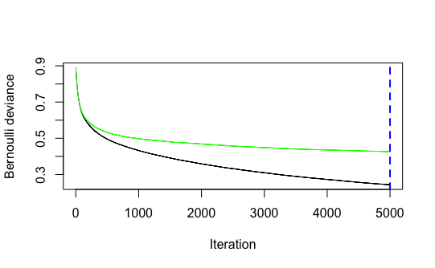

```r
# reproducibility
set.seed(123)

gbm19 <- gbm(Churn ~ .,
                 data = top.9.train,
                 distribution = 'bernoulli', #for classifcation
                   n.trees = 5000,            #The parameter M
                   shrinkage = 0.01,          #The value lambda, default = .01
                   interaction.depth = 3,      #interactions between x's
                   cv.folds = 10)                # K > 0 for cv

## Find the estimated optimal number of iterations
perf_gbm19 = gbm.perf(gbm19, method="cv")
```

```r
perf_gbm19
```

```
[1] 5000
```

```r
# Training error
pred1gbm19 <- predict(gbm19, newdata = top.9.train, n.trees=perf_gbm19, type="response")
pred1gbm19[1:10]
```

```
 [1] 0.3409232 0.8840312 0.9902300 0.7975913 0.7331385 0.8851195 0.4578862 0.9879079 0.6642375 0.6725290
```

```r
y1hat19 <- ifelse(pred1gbm19 < 0.5, 0, 1)
y1hat19[1:10]
```

```
 [1] 0 1 1 1 1 1 0 1 1 1
```

```r
sum(y1hat19 != y1)/length(y1)  ##Training error
```

```
[1] 0.04133545
```

Boosting A w top 9 Testing Error

```r
## Testing Error
y2hat19 <- ifelse(predict(gbm19, newdata = top.9.test[,-1], n.trees=perf_gbm19,type="response") < 0.5, 0, 1)
c9 <- mean(y2hat19 != y2)
c9
```

```
[1] 0.08426073
```

1 = Y = church: 35 columns total, so 2:35 are all predictor variables

rfb9 Let’s go back and run the top 9 predictors on the optimized rfb, as it has only been run on all the data

```r
set.seed(123)
#no of rows train data = 2516; no of rows test data = 1258
rfb9 <- randomForest(as.factor(Churn) ~., data=top.9.train, ntree= 500,
                   mtry = 4, nodesize = 1,  importance = TRUE)
```

RF: Training error prediction & confusion matrix

```r
rfb9.pred.train = predict(rfb9, top.9.train, type='class')
table(rfb9.pred.train, y1)
```

```
               y1
rfb9.pred.train    0    1
              0 2100    0
              1    0  416
```

RF: Test error prediction & confusion matrix

```r
rfb9.pred.test = predict(rfb9, top.9.test, type='class')
table(rfb9.pred.test, y2)
```

```
              y2
rfb9.pred.test    0    1
             0 1028   33
             1   15  182
```

RF: Test error rate

```r
#.038
y2hat.rfb9.test = predict(rfb9, top.9.test, type='class')
b9 <- mean(y2hat.rfb9.test != y2)
b9
```

```
[1] 0.0381558
```

## C. LDA

```r
#B.Linear Discriminant Analysis : 0.1041667
#Test error rate LDA
library(MASS)
set.seed(123)
modB <- lda(train[,2:35], train[,1])
y2hatB <- predict(modB, test[,-1])$class
e <- mean( y2hatB  != y2)
e
```

```
[1] 0.1168521
```

```r
#B.Linear Discriminant Analysis :w top 9  0.1041667
library(MASS)
set.seed(123)
modB9 <- lda(top.9.train[,2:10], top.9.train[,1])
y2hatB9 <- predict(modB9, top.9.test[,-1])$class
e9 <- mean( y2hatB9  != y2)
e9
```

```
[1] 0.1311606
```

## D Naive Bayes

```r
## C. Naive Bayes (with full X). Testing error = 0.313151
#entire data set
library(e1071)
set.seed(123)
modC <- naiveBayes(as.factor(Churn) ~. , data = train)
y2hatC <- predict(modC, newdata = test)
f <- mean( y2hatC != y2)
f
```

```
[1] 0.3235294
```

NB w top 9

```r
## C. Naive Bayes (with full X). Testing error = 0.313151

set.seed(123)
modC9 <- naiveBayes(as.factor(Churn) ~. , data = top.9.train)
y2hatC9 <- predict(modC9, newdata = top.9.test)
f9 <- mean( y2hatC9 != y2)
f9
```

```
[1] 0.136725
```

## E Classification tree

```r
#D: a single Tree: 0.1015625
library(rpart)
set.seed(123)
modE0 <- rpart(Churn ~ .,data=train, method="class",
                     parms=list(split="gini"))
opt <- which.min(modE0$cptable[, "xerror"]);
cp1 <- modE0$cptable[opt, "CP"];
modE <- prune(modE0,cp=cp1);
y2hatE <-  predict(modE, test[,-1],type="class")
g <- mean(y2hatE != y2)
g
```

```
[1] 0.1041335
```

Classification tree top 9

```r
#D: a single Tree: 0.1015625

set.seed(123)
modE09 <- rpart(Churn ~ .,data=top.9.train, method="class",
                     parms=list(split="gini"))
opt9 <- which.min(modE09$cptable[, "xerror"]);
cp19 <- modE09$cptable[opt9, "CP"];
modE9 <- prune(modE09,cp=cp19);
y2hatE9 <-  predict(modE9, top.9.test[,-1],type="class")
g9 <- mean(y2hatE9 != y2)
g9
```

```
[1] 0.09856916
```

## Summary Tables

```r
#Method <- c('RF1', 'RF2', 'Bst1', 'Bst2', 'LDA', 'NB', 'Tree')
All_34 <- c(a, b, c, d, e, f, g)
Top_9 <- c(a9, b9, c9, d9, e9, f9, g9)

TE <- data.frame(All_34, Top_9)

rownames(TE) <- c('RF1', 'RF2', 'Bst1', 'Bst2', 'LDA', 'NB', 'Tree')
TE
```

|  | All_34 | Top_9 |
| --- | --- | --- |
| RF1 | 0.03895072 | 0.03736089 |
| RF2 | 0.03338633 | 0.03815580 |
| Bst1 | 0.07392687 | 0.08426073 |
| Bst2 | 0.06041335 | 0.06041335 |
| LDA | 0.11685215 | 0.13116057 |
| NB | 0.32352941 | 0.13672496 |
| Tree | 0.10413355 | 0.09856916 |

Make a graph

```r
TE["Model" ] <- rownames(TE)
TE.Summary <- melt(TE)
```

```r
TE.Summary
```

| Model | variable | value |
| --- | --- | --- |
| RF1 | All_34 | 0.03895072 |
| RF2 | All_34 | 0.03338633 |
| Bst1 | All_34 | 0.07392687 |
| Bst2 | All_34 | 0.06041335 |
| LDA | All_34 | 0.11685215 |
| NB | All_34 | 0.32352941 |
| Tree | All_34 | 0.10413355 |
| RF1 | Top_9 | 0.03736089 |
| RF2 | Top_9 | 0.03815580 |
| Bst1 | Top_9 | 0.08426073 |

[output cut: 4 more lines]

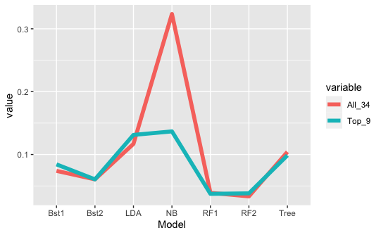

```r
ggplot(TE.Summary, aes(x = Model, y = value, group = variable, colour = variable)) +
            geom_line(size = 2)
```

Calculate the Delta in TE data <- data.frame(A = c(1,2,3,4), B = c(2,2,2,2)) data$C <- (data$A - data$B)

Difference or Delta between of all 34 predictors vs. the top 9; #auto6 <- auto4[c(“mpg”, “horsepower”, “weight”)]

```r
#library(dplyr)
TE.d <- TE

TE.d$Delta <- round((TE.d$All_34 - TE.d$Top_9),4)
TE.d2 <- TE.d[c("All_34", "Top_9", "Delta")]
#TE.d2 <- TE.d[c("All_34", "Top_9", "Delta")]
TE.d3 <- round(TE.d2, 4)
TE.d3
```

|  | All_34 | Top_9 | Delta |
| --- | --- | --- | --- |
| RF1 | 0.0390 | 0.0374 | 0.0016 |
| RF2 | 0.0334 | 0.0382 | -0.0048 |
| Bst1 | 0.0739 | 0.0843 | -0.0103 |
| Bst2 | 0.0604 | 0.0604 | 0.0000 |
| LDA | 0.1169 | 0.1312 | -0.0143 |
| NB | 0.3235 | 0.1367 | 0.1868 |
| Tree | 0.1041 | 0.0986 | 0.0056 |

```r
typeof(TE.d)
```

```
[1] "list"
```

#### REFERENCE

1. This is the Ecommerce Data set, available from https://www.kaggle.com/datasets/ankitverma2010/ecommerce-customer-churn-analysis-and-prediction
2. MICE: filling in missing values: do if time? https://towardsdatascience.com/smart-handling-of-missing-data-in-r-6425f8a559f2
3. Geting various model performance scores in carret, ie ROC https://topepo.github.io/caret/variable-importance.html
4. https://stackoverflow.com/questions/48649443/how-to-one-hot-encode-several-categorical-variables-in-r